# Ranking 200 mejores nadadores por prueba

Cueva Tomas

2023-01-12

# Analisis exploratorio de los 200 mejores tiempos por carrera

## Pre entrega Cueva Tomas

En este Rmarkdown realizaremos el analisis de un dataset el cual contiene a los 200 mejores tiempos historicos de cada carrera, con nadadores dentro del ambito profesional. Del cual vamos a analizar:

- **La cantidad de nadadores por equipo/país** para analizar donde es que se concentra la mejor escuela de nadadores a nivel profesional
- La edad promedio en donde los nadadores consiguen su rendimiento más alto
- La diferencia competitiva entre hombres y mujeres a nivel profesional

Importamos librerias

Leemos el dataset y analizamos sus caracteristicas

```r
data <- read.csv("../data/best_swimmers.csv",sep = ",")

na <- sum(is.na(data))

description <- ''

if(na == 0){
    description <- "El dataframe no tiene valores na"
  }else{
    decription <- "El dataframe SI TIENE valores na"
  }

description <-cat(description , " , contiene " , nrow(data), " filas y ",ncol(data), " columnas",", con las siguientes variables: ",names(data))
```

```
## El dataframe no tiene valores na  , contiene  5200  filas y  14  columnas , con las siguientes variables:  index Event.Name Swim.time Swim.date Event.description Team.Code Team.Name Athlete.Full.Name Gender Athlete.birth.date Rank_Order City Country.Code Duration..hh.mm.ss.ff.
```

Transformamos los datos para facilitar el uso de operaciones, en donde:

- Pasaremos las fechas de tipo caracter a tipo Date
- Nombre y codigo de los equipos a tipo factor
- Crearemos una nueva columna para vizualizar la edad del nadador en el momento que realizó aquel tiempo de nado que le permitió estar en este ranking

```r
data <- data %>%
  mutate(
    Swim.date = as.Date(Swim.date,format = "%m-%d-%y"),
    Athlete.birth.date = as.Date(Athlete.birth.date,format = "%m-%d-%y"),
    Team.Code = as.factor(Team.Code),
    Team.Name = as.factor(Team.Name),
    Age.to.swim = trunc(as.numeric((`Swim.date`- `Athlete.birth.date`)/365))
  )
```

### Cantidad de nadadores por equipo

```r
data %>%
  select(Athlete.Full.Name,Team.Code,Team.Name) %>%
  unique() %>%
  group_by(Team.Code,Team.Name) %>%
  transmute(
    Team.Code = as.factor(Team.Code),
    id.team.code = as.factor(Team.Code),
    id.team.code = as.integer(id.team.code)
  ) %>%
  summarise(
    Amount.Swimmers = sum(id.team.code/id.team.code)
  ) %>%
  arrange(desc(Amount.Swimmers)) %>%
  slice(1:10) %>%
  DT::datatable(
    rownames = F,
    filter = "top"
  )
```

| Team.Code | Team.Name | Amount.Swimmers |
| --- | --- | --- |
| ARG | Argentina | 1 |
| AUS | Australia | 83 |
| AUT | Austria | 5 |
| BAH | Bahamas | 1 |
| BEL | Belgium | 1 |
| BLR | Belarus | 3 |
| BRA | Brazil | 14 |
| BUL | Bulgaria | 2 |
| CAN | Canada | 28 |
| CHI | Chile | 1 |

[output cut: 48 more lines]

### Edad promedio de redimiento optimo, visualización

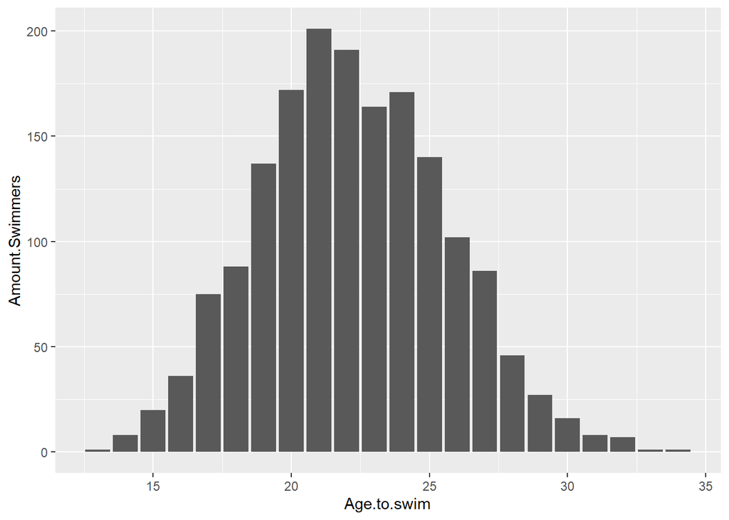

```r
plot_performance <- data %>%
  select(Athlete.Full.Name, Age.to.swim) %>%
  unique() %>%
  group_by(Age.to.swim) %>%
  summarise(
    Amount.Swimmers = sum(Age.to.swim/Age.to.swim)
  ) %>%
  arrange(desc(Amount.Swimmers))

plot_performance <- plot_performance %>%
  filter(Age.to.swim > 0)

ggplot(
  data =plot_performance,
  mapping = aes(
    x =Age.to.swim,
    y = Amount.Swimmers)
  ) +
  geom_bar( stat = "identity")
```

### Competitividad, hombres vs mujeres

En el siguiente grafico se buscó visualizar la proporción de hombres y mujeres en cada equipo.

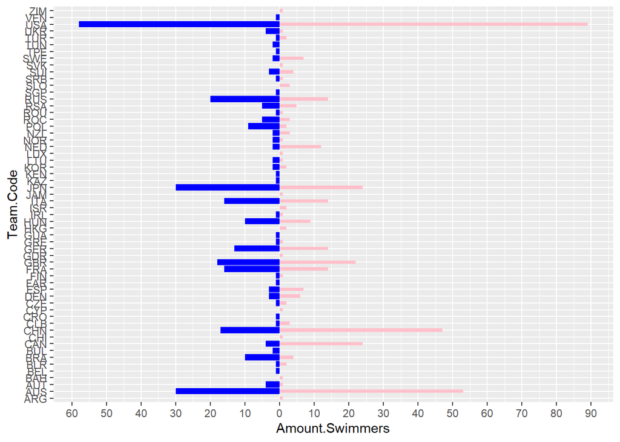

```r
female_df <- gender_select(data,"F")

male_df <- gender_select(data,"M")

genders <- full_join(female_df,male_df)

genders <-genders %>%
  arrange(desc(Team.Code))

ggplot(genders,aes(x = `Team.Code`,
                   y = `Amount.Swimmers`,
                   fill = Gender)) +
  geom_col(data = subset(genders,Gender == "M") %>%
             mutate(`Amount.Swimmers` = -`Amount.Swimmers`),
           width = 0.9,fill = "blue")+
  geom_col(data = subset(genders,Gender == "F"),width = 0.5,fill = "pink")+
  coord_flip() +
  scale_y_continuous(breaks = c(seq(-100,-10,by = 10),seq(0,100,by = 10)),labels = c(seq(-100,-10,by = 10)* -1,seq(0,100,by = 10)))
```